# 重賞レース予測レポート【毎時自動更新中】

作成日時: 2025/09/21 12:05:18

☞ [マニュアル(pdf)](https://ryutoro-galois.github.io/keiba-predictor/manual/manual.pdf)

☞ 過去5年の同一レース結果: [2024年](https://ryutoro-galois.github.io/keiba-predictor/report/PredResult_2024y_raceDate_20240922_20240922.html), [2023年](https://ryutoro-galois.github.io/keiba-predictor/report/PredResult_2023y_raceDate_20230924_20230924.html), [2022年](https://ryutoro-galois.github.io/keiba-predictor/report/PredResult_2022y_raceDate_20220925_20220925.html), [2021年](https://ryutoro-galois.github.io/keiba-predictor/report/PredResult_2021y_raceDate_20210926_20210926.html), [2020年](https://ryutoro-galois.github.io/keiba-predictor/report/PredResult_2020y_raceDate_20200927_20200927.html)

☞ 過去4週間の別レース結果: [1週前(9/13-15)](https://ryutoro-galois.github.io/keiba-predictor/report/PredResult_2025y_raceDate_20250913_20250915.html), [2週前(9/6-7)](https://ryutoro-galois.github.io/keiba-predictor/report/PredResult_2025y_raceDate_20250906_20250907.html), [3週前(8/31)](https://ryutoro-galois.github.io/keiba-predictor/report/PredResult_2025y_raceDate_20250831_20250831.html), [4週前(8/24)](https://ryutoro-galois.github.io/keiba-predictor/report/PredResult_2025y_raceDate_20250824_20250824.html)

☞ netkeiba: [阪神ジャンプステークス(JGⅢ)](https://race.netkeiba.com/race/shutuba.html?race_id=202509040604&rf=race_list), [オールカマー(GⅡ)](https://race.netkeiba.com/race/shutuba.html?race_id=202506040711&rf=race_list), [神戸新聞杯(GⅡ)](https://race.netkeiba.com/race/shutuba.html?race_id=202509040711&rf=race_list)

## 0. 推し馬予測 (AI予測)

### 【阪神ジャンプステークス(J.GⅢ) 2025/09/20(土)】

- 本命(◎): 1-3着内確率(勝負強さ)が1位の馬
- 対抗(◯): 1-3着内確率が2-N位(20%程度以上)の中で予測タイムが最も速い馬
- 3番手(▲): 1-3着内確率が2-N位(20%程度以上)のでダークホース確率が最も高い馬
- 穴: ダークホース確率が上位1-M位(40%程度以上)の中で1-3着内確率が最も高い馬

| 推し馬 | 枠番 | 馬番 | 人気 | オッズ | 馬名 | 騎手 | 調教師 | 予測タイム(sec) | 1_順位 | 1-3着内確率(%) | 2_順位 | ﾀﾞｰｸﾎｰｽ確率(%) | 3_順位 |
| --- | --- | --- | --- | --- | --- | --- | --- | --- | --- | --- | --- | --- | --- |
| 本命(◎) | 8 | 9 | 3 | 10.6 | マテンロウジョイ | 西谷誠 | 四位洋文 | 222.0 | 4 | 17.4 | 1 | 1.6 | 5 |
| 対抗(◯) | 5 | 5 | 1 | 1.7 | ジューンベロシティ | 高田潤 | 武英智 | 204.8 | 1 | 14.2 | 2 | 0.4 | 9 |
| 3番手(▲) | 2 | 2 | 8 | 125.4 | サンマルグレイト | 大江原圭 | 佐藤吉勝 | 222.1 | 5 | 8.7 | 6 | 54.4 | 2 |
| 穴 | 1 | 1 | 9 | 131.6 | ポリトナリティー | 上野翔 | 和田雄二 | 222.3 | 6 | 8.6 | 7 | 54.4 | 1 |

### 【オールカマー(GⅡ) 2025/09/21(日)】

- 本命(◎): 1-3着内確率(勝負強さ)が1位の馬
- 対抗(◯): 1-3着内確率が2-N位(20%程度以上)の中で予測タイムが最も速い馬
- 3番手(▲): 1-3着内確率が2-N位(20%程度以上)のでダークホース確率が最も高い馬
- 穴: ダークホース確率が上位1-M位(40%程度以上)の中で1-3着内確率が最も高い馬

| 推し馬 | 枠番 | 馬番 | 人気 | オッズ | 馬名 | 騎手 | 調教師 | 予測タイム(sec) | 1_順位 | 1-3着内確率(%) | 2_順位 | ﾀﾞｰｸﾎｰｽ確率(%) | 3_順位 |
| --- | --- | --- | --- | --- | --- | --- | --- | --- | --- | --- | --- | --- | --- |
| 本命(◎) | 6 | 7 | 5 | 8.4 | ヨーホーレイク | 岩田望来 | 友道康夫 | 133.9 | 2 | 23.9 | 1 | 1.4 | 7 |
| 対抗(◯) | 4 | 4 | 1 | 3.6 | レガレイラ | 戸崎圭太 | 木村哲也 | 131.2 | 1 | 23.1 | 2 | 0.5 | 11 |
| 3番手(▲) | 3 | 3 | 7 | 11.6 | クロミナンス | Ｊ．モレイラ | 尾関知人 | 135.0 | 3 | 22.4 | 3 | 50.0 | 1 |
| 穴 | 2 | 2 | 6 | 11.5 | リビアングラス | 鮫島克駿 | 矢作芳人 | 144.0 | 6 | 16.4 | 7 | 1.8 | 6 |

### 【神戸新聞杯(GⅡ) 2025/09/21(日)】

- 本命(◎): 1-3着内確率(勝負強さ)が1位の馬
- 対抗(◯): 1-3着内確率が2-N位(20%程度以上)の中で予測タイムが最も速い馬
- 3番手(▲): 1-3着内確率が2-N位(20%程度以上)のでダークホース確率が最も高い馬
- 穴: ダークホース確率が上位1-M位(40%程度以上)の中で1-3着内確率が最も高い馬

| 推し馬 | 枠番 | 馬番 | 人気 | オッズ | 馬名 | 騎手 | 調教師 | 予測タイム(sec) | 1_順位 | 1-3着内確率(%) | 2_順位 | ﾀﾞｰｸﾎｰｽ確率(%) | 3_順位 |
| --- | --- | --- | --- | --- | --- | --- | --- | --- | --- | --- | --- | --- | --- |
| 本命(◎) | 8 | 10 | 2 | 3.0 | エリキング | 川田将雅 | 中内田充正 | 145.1 | 2 | 26.4 | 1 | 0.9 | 9 |
| 対抗(◯) | 5 | 5 | 1 | 2.9 | ショウヘイ | 坂井瑠星 | 友道康夫 | 144.4 | 1 | 21.0 | 2 | 0.8 | 10 |
| 3番手(▲) | 6 | 6 | 7 | 20.2 | サンライズバブル | 池添謙一 | 新谷功一 | 158.0 | 6 | 12.3 | 5 | 44.0 | 4 |
| 穴 | 4 | 4 | 6 | 14.3 | ジョイボーイ | 藤岡佑介 | 四位洋文 | 158.0 | 6 | 10.9 | 7 | 42.1 | 5 |

## 1. 予測チャート (タイム/勝負強さ)

### 【阪神ジャンプステークス(J.GⅢ)】

2025/09/20(土), 09_阪神, 障芝3140m

[interactive chart not shown]

### 【オールカマー(GⅡ)】

2025/09/21(日), 06_中山, 芝右外2200m

[interactive chart not shown]

### 【神戸新聞杯(GⅡ)】

2025/09/21(日), 09_阪神, 芝右外2400m

[interactive chart not shown]

## 2. オッズモニタリング (毎時)

### 【阪神ジャンプステークス】

[interactive chart not shown]

### 【オールカマー】

[interactive chart not shown]

### 【神戸新聞杯】

[interactive chart not shown]

## 3. 出馬表

### 【阪神ジャンプステークス 2025/09/20(土) 】

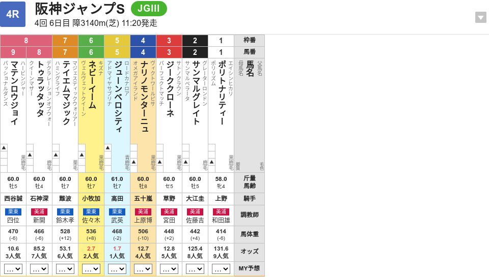

### 【オールカマー 2025/09/21(日) 】

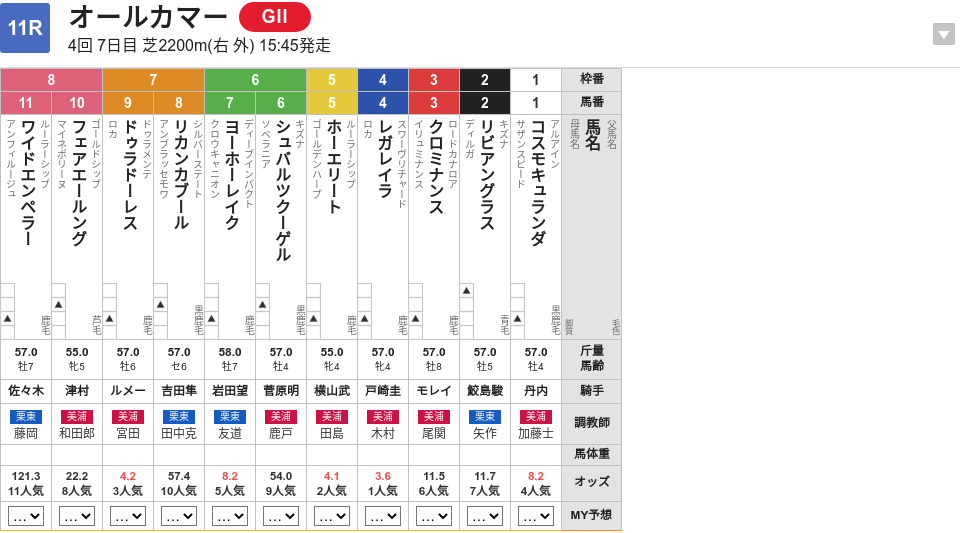

### 【神戸新聞杯 2025/09/21(日) 】

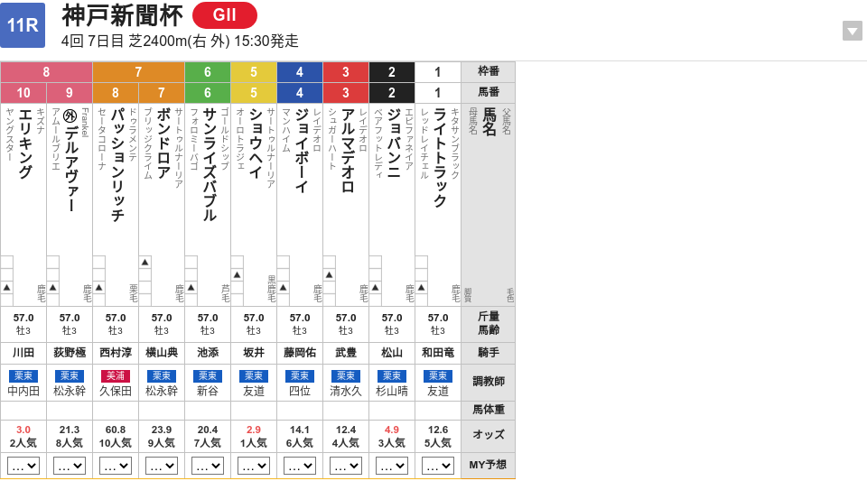

## 4. 単勝予測結果

### 【阪神ジャンプステークス(J.GⅢ) 2025/09/20(土)】

| 枠番 | 馬番 | 人気 | オッズ | 馬名 | 騎手 | 調教師 | 予測タイム(sec) | 1_順位 | 1-3着内確率(%) | 2_順位 | ﾀﾞｰｸﾎｰｽ確率(%) | 3_順位 |
| --- | --- | --- | --- | --- | --- | --- | --- | --- | --- | --- | --- | --- |
| 1 | 1 | 9 | 131.6 | ポリトナリティー | 上野翔 | 和田雄二 | 222.3 | 6 | 8.6 | 7 | 54.4 | 1 |
| 2 | 2 | 8 | 125.4 | サンマルグレイト | 大江原圭 | 佐藤吉勝 | 222.1 | 5 | 8.7 | 6 | 54.4 | 2 |
| 3 | 3 | 5 | 12.8 | ジーククローネ | 草野太郎 | 宮田敬介 | 222.4 | 7 | 10.2 | 5 | 1.5 | 6 |
| 4 | 4 | 4 | 12.7 | ナリノモンターニュ | 五十嵐雄祐 | 上原博之 | 215.2 | 2 | 11.0 | 4 | 1.1 | 7 |
| 5 | 5 | 1 | 1.7 | ジューンベロシティ | 高田潤 | 武英智 | 204.8 | 1 | 14.2 | 2 | 0.4 | 9 |
| 6 | 6 | 2 | 2.7 | ネビーイーム | 小牧加矢太 | 佐々木晶三 | 223.0 | 8 | 13.5 | 3 | 0.4 | 8 |
| 7 | 7 | 6 | 53.1 | テイエムマジック | 難波剛健 | 鈴木孝志 | 223.5 | 9 | 3.1 | 9 | 8.2 | 4 |
| 8 | 8 | 7 | 85.2 | トゥラッタッタ | 石神深一 | 新開幸一 | 221.9 | 3 | 8.5 | 8 | 41.0 | 3 |
| 8 | 9 | 3 | 10.6 | マテンロウジョイ | 西谷誠 | 四位洋文 | 222.0 | 4 | 17.4 | 1 | 1.6 | 5 |

### 【オールカマー(GⅡ) 2025/09/21(日)】

| 枠番 | 馬番 | 人気 | オッズ | 馬名 | 騎手 | 調教師 | 予測タイム(sec) | 1_順位 | 1-3着内確率(%) | 2_順位 | ﾀﾞｰｸﾎｰｽ確率(%) | 3_順位 |
| --- | --- | --- | --- | --- | --- | --- | --- | --- | --- | --- | --- | --- |
| 1 | 1 | 4 | 8.3 | コスモキュランダ | 丹内祐次 | 加藤士津八 | 147.0 | 11 | 18.5 | 6 | 0.9 | 8 |
| 2 | 2 | 6 | 11.5 | リビアングラス | 鮫島克駿 | 矢作芳人 | 144.0 | 6 | 16.4 | 7 | 1.8 | 6 |
| 3 | 3 | 7 | 11.6 | クロミナンス | Ｊ．モレイラ | 尾関知人 | 135.0 | 3 | 22.4 | 3 | 50.0 | 1 |
| 4 | 4 | 1 | 3.6 | レガレイラ | 戸崎圭太 | 木村哲也 | 131.2 | 1 | 23.1 | 2 | 0.5 | 11 |
| 5 | 5 | 2 | 4.1 | ホーエリート | 横山武史 | 田島俊明 | 146.3 | 10 | 18.7 | 5 | 0.7 | 9 |
| 6 | 6 | 9 | 53.7 | シュバルツクーゲル | 菅原明良 | 鹿戸雄一 | 143.1 | 5 | 9.1 | 8 | 29.7 | 2 |
| 6 | 7 | 5 | 8.4 | ヨーホーレイク | 岩田望来 | 友道康夫 | 133.9 | 2 | 23.9 | 1 | 1.4 | 7 |
| 7 | 8 | 10 | 56.5 | リカンカブール | 吉田隼人 | 田中克典 | 145.7 | 9 | 3.5 | 11 | 29.6 | 3 |
| 7 | 9 | 3 | 4.2 | ドゥラドーレス | Ｃ．ルメール | 宮田敬介 | 142.6 | 4 | 20.6 | 4 | 0.5 | 10 |
| 8 | 10 | 8 | 22.2 | フェアエールング | 津村明秀 | 和田正一郎 | 145.6 | 8 | 3.9 | 9 | 7.6 | 5 |

[output cut: 1 more lines]

### 【神戸新聞杯(GⅡ) 2025/09/21(日)】

| 枠番 | 馬番 | 人気 | オッズ | 馬名 | 騎手 | 調教師 | 予測タイム(sec) | 1_順位 | 1-3着内確率(%) | 2_順位 | ﾀﾞｰｸﾎｰｽ確率(%) | 3_順位 |
| --- | --- | --- | --- | --- | --- | --- | --- | --- | --- | --- | --- | --- |
| 1 | 1 | 5 | 12.8 | ライトトラック | 和田竜二 | 友道康夫 | 158.0 | 6 | 11.7 | 6 | 1.6 | 7 |
| 2 | 2 | 3 | 4.9 | ジョバンニ | 松山弘平 | 杉山晴紀 | 161.6 | 10 | 19.6 | 3 | 1.0 | 8 |
| 3 | 3 | 4 | 12.2 | アルマデオロ | 武豊 | 清水久詞 | 158.0 | 6 | 14.6 | 4 | 1.7 | 6 |
| 4 | 4 | 6 | 14.3 | ジョイボーイ | 藤岡佑介 | 四位洋文 | 158.0 | 6 | 10.9 | 7 | 42.1 | 5 |
| 5 | 5 | 1 | 2.9 | ショウヘイ | 坂井瑠星 | 友道康夫 | 144.4 | 1 | 21.0 | 2 | 0.8 | 10 |
| 6 | 6 | 7 | 20.2 | サンライズバブル | 池添謙一 | 新谷功一 | 158.0 | 6 | 12.3 | 5 | 44.0 | 4 |
| 7 | 7 | 9 | 23.9 | ボンドロア | 横山典弘 | 松永幹夫 | 158.0 | 6 | 10.0 | 9 | 54.6 | 2 |
| 7 | 8 | 10 | 60.5 | パッションリッチ | 西村淳也 | 久保田貴士 | 158.0 | 6 | 10.0 | 9 | 55.0 | 1 |
| 8 | 9 | 8 | 21.5 | デルアヴァー | 荻野極 | 松永幹夫 | 158.0 | 6 | 10.0 | 9 | 45.9 | 3 |
| 8 | 10 | 2 | 3.0 | エリキング | 川田将雅 | 中内田充正 | 145.1 | 2 | 26.4 | 1 | 0.9 | 9 |

## 5. 人気と着順の乖離率推移

### 【阪神ジャンプステークス_2001y_2019y】

[interactive chart not shown]

### 【オールカマー_1990y_2019y】

[interactive chart not shown]

### 【神戸新聞杯_1990y_2019y】

[interactive chart not shown]

### 【阪神ジャンプステークス_2001y_2019y】

| No | 開催年 | 不整合率(%) | 頭数 | 人気別着順(1-3位) | 人気別着順(全体) |
| --- | --- | --- | --- | --- | --- |
| 19 | 2019 | 27.6 | 11頭 | 4-1-6 | 4\|1\|6\|2\|7\|11\|12\|3\|5\|8\|9 |
| 18 | 2018 | 35.1 | 9頭 | 1-4-6 | 1\|4\|6\|3\|2\|7\|5\|9\|8 |
| 17 | 2017 | 33.6 | 6頭 | 1-4-6 | 1\|4\|6\|5\|2\|7 |
| 16 | 2016 | 8.2 | 11頭 | 1-2-10 | 1\|2\|10\|3\|5\|4\|8\|7\|9\|6\|11 |
| 15 | 2015 | 18.5 | 8頭 | 1-2-9 | 1\|2\|9\|6\|4\|7\|8\|3 |
| 14 | 2014 | 11.1 | 11頭 | 1-6-2 | 1\|6\|2\|3\|5\|4\|8\|9\|10\|12\|11 |
| 13 | 2013 | 25.4 | 13頭 | 2-1-3 | 2\|1\|3\|9\|6\|10\|5\|8\|4\|12\|11\|14\|13 |
| 12 | 2012 | 48.8 | 11頭 | 4-7-1 | 4\|7\|1\|5\|8\|6\|12\|11\|10\|9\|3 |
| 11 | 2011 | 34.5 | 14頭 | 6-1-5 | 6\|1\|5\|8\|4\|2\|12\|3\|10\|7\|13\|14\|11\|9 |
| 10 | 2010 | 36.1 | 14頭 | 1-8-9 | 1\|8\|9\|3\|5\|4\|11\|12\|13\|7\|2\|6\|14\|10 |

[output cut: 9 more lines]

### 【オールカマー_1990y_2019y】

| No | 開催年 | 不整合率(%) | 頭数 | 人気別着順(1-3位) | 人気別着順(全体) |
| --- | --- | --- | --- | --- | --- |
| 30 | 2019 | 58.1 | 10頭 | 4-3-6 | 4\|3\|6\|1\|5\|7\|8\|10\|2\|9 |
| 29 | 2018 | 21.9 | 12頭 | 1-3-2 | 1\|3\|2\|5\|9\|7\|4\|11\|12\|8\|6\|10 |
| 28 | 2017 | 36.6 | 17頭 | 5-1-3 | 5\|1\|3\|10\|13\|14\|4\|8\|2\|7\|15\|9\|6\|12\|11\|17\|16 |
| 27 | 2016 | 26.4 | 12頭 | 1-3-6 | 1\|3\|6\|4\|2\|8\|5\|11\|7\|9\|12\|10 |
| 26 | 2015 | 34.3 | 15頭 | 3-1-7 | 3\|1\|7\|2\|4\|14\|10\|13\|9\|8\|5\|11\|15\|6\|12 |
| 25 | 2014 | 58.4 | 18頭 | 2-7-12 | 2\|7\|12\|14\|6\|4\|5\|16\|10\|11\|9\|13\|18\|3\|17\|1\|15\|8 |
| 24 | 2013 | 36.9 | 16頭 | 9-2-1 | 9\|2\|1\|5\|7\|8\|6\|4\|3\|10\|13\|12\|16\|15\|14\|11 |
| 23 | 2012 | 36.7 | 15頭 | 2-4-6 | 2\|4\|6\|1\|9\|10\|13\|11\|3\|15\|8\|12\|14\|7\|5 |
| 22 | 2011 | 18.3 | 9頭 | 1-6-2 | 1\|6\|2\|7\|4\|3\|8\|9\|5 |
| 21 | 2010 | 23.9 | 10頭 | 5-1-6 | 5\|1\|6\|7\|2\|3\|10\|9\|4\|8 |

[output cut: 20 more lines]

### 【神戸新聞杯_1990y_2019y】

| No | 開催年 | 不整合率(%) | 頭数 | 人気別着順(1-3位) | 人気別着順(全体) |
| --- | --- | --- | --- | --- | --- |
| 30 | 2019 | 1.8 | 8頭 | 1-2-3 | 1\|2\|3\|4\|6\|5\|7\|8 |
| 29 | 2018 | 36.0 | 10頭 | 2-3-6 | 2\|3\|6\|1\|4\|8\|9\|5\|7\|10 |
| 28 | 2017 | 4.5 | 14頭 | 1-2-3 | 1\|2\|3\|4\|8\|5\|7\|13\|6\|9\|12\|10\|11\|14 |
| 27 | 2016 | 25.7 | 15頭 | 1-6-4 | 1\|6\|4\|5\|2\|3\|10\|7\|9\|8\|13\|11\|14\|12\|15 |
| 26 | 2015 | 46.0 | 15頭 | 3-1-7 | 3\|1\|7\|8\|14\|9\|4\|13\|10\|11\|6\|12\|2\|5\|15 |
| 25 | 2014 | 22.5 | 16頭 | 1-8-9 | 1\|8\|9\|2\|6\|5\|3\|7\|16\|14\|11\|10\|4\|12\|13\|15 |
| 24 | 2013 | 21.3 | 18頭 | 1-7-2 | 1\|7\|2\|8\|6\|16\|3\|5\|13\|9\|11\|12\|14\|15\|17\|10\|4\|18 |
| 23 | 2012 | 17.2 | 15頭 | 1-8-2 | 1\|8\|2\|9\|10\|14\|3\|6\|5\|4\|7\|11\|12\|15\|13 |
| 22 | 2011 | 5.5 | 11頭 | 1-2-3 | 1\|2\|3\|5\|4\|7\|8\|6\|10\|9\|11 |
| 21 | 2010 | 28.4 | 12頭 | 2-1-5 | 2\|1\|5\|10\|3\|8\|11\|7\|6\|4\|12\|9 |

[output cut: 20 more lines]

## 6. 1-3番人気馬の着順分類予測

### 【阪神ジャンプステークス】

| 分類 | 凡例 | 発生確率(%) | 当該レース | 当該レースランク | 直近1年間 |
| --- | --- | --- | --- | --- | --- |
| 1: 1番人気のみ (1_pop1) | 1 \| * \| * | 17.7 | 0.35 | 0.40 | 0.53 |
| 4: 1,2番人気のみ (4_pop12) | 1 \| 2 \| * | 16.8 | 0.81 | 0.81 | 0.00 |
| 5: 1,3番人気のみ (5_pop13) | 1 \| 3 \| * | 14.5 | 3.45 | 2.10 | 0.00 |
| 8: 1,2,3番人気すべて着外 (8_darkhorse) | * \| * \| * | 14.5 | 0.87 | 0.70 | 0.00 |
| 2: 2番人気のみ (2_pop2) | 2 \| * \| * | 10.0 | 0.00 | 0.00 | 0.00 |
| 6: 2,3番人気のみ (6_pop23) | 2 \| 3 \| * | 10.0 | 0.00 | 0.00 | 0.00 |
| 3: 3番人気のみ (3_pop3) | 3 \| * \| * | 9.2 | 0.00 | 0.00 | 0.28 |
| 7: 1,2,3番人気すべて着内 (7_pop123) | 1 \| 2 \| 3 | 7.2 | 0.87 | 1.04 | 0.22 |

### 【オールカマー】

| 分類 | 凡例 | 発生確率(%) | 当該レース | 当該レースランク | 直近1年間 |
| --- | --- | --- | --- | --- | --- |
| 1: 1番人気のみ (1_pop1) | 1 \| * \| * | 17.7 | 1.04 | 1.28 | 0.00 |
| 4: 1,2番人気のみ (4_pop12) | 1 \| 2 \| * | 16.8 | 1.17 | 0.99 | 0.00 |
| 5: 1,3番人気のみ (5_pop13) | 1 \| 3 \| * | 14.5 | 1.01 | 1.58 | 0.00 |
| 8: 1,2,3番人気すべて着外 (8_darkhorse) | * \| * \| * | 14.5 | 1.69 | 1.88 | 0.00 |
| 2: 2番人気のみ (2_pop2) | 2 \| * \| * | 10.0 | 0.70 | 1.30 | 0.00 |
| 6: 2,3番人気のみ (6_pop23) | 2 \| 3 \| * | 10.0 | 1.75 | 1.09 | 0.00 |
| 3: 3番人気のみ (3_pop3) | 3 \| * \| * | 9.2 | 0.54 | 0.85 | 0.18 |
| 7: 1,2,3番人気すべて着内 (7_pop123) | 1 \| 2 \| 3 | 7.2 | 0.84 | 0.29 | 0.14 |

### 【神戸新聞杯】

| 分類 | 凡例 | 発生確率(%) | 当該レース | 当該レースランク | 直近1年間 |
| --- | --- | --- | --- | --- | --- |
| 1: 1番人気のみ (1_pop1) | 1 \| * \| * | 16.7 | 1.46 | 1.21 | 0.00 |
| 4: 1,2番人気のみ (4_pop12) | 1 \| 2 \| * | 16.4 | 0.82 | 0.97 | 0.00 |
| 3: 3番人気のみ (3_pop3) | 3 \| * \| * | 14.7 | 5.07 | 1.36 | 0.29 |
| 5: 1,3番人気のみ (5_pop13) | 1 \| 3 \| * | 13.8 | 2.42 | 1.50 | 0.00 |
| 8: 1,2,3番人気すべて着外 (8_darkhorse) | * \| * \| * | 13.1 | 1.15 | 1.70 | 0.00 |
| 2: 2番人気のみ (2_pop2) | 2 \| * \| * | 9.8 | 0.00 | 1.27 | 0.00 |
| 6: 2,3番人気のみ (6_pop23) | 2 \| 3 \| * | 8.5 | 0.75 | 0.92 | 0.00 |
| 7: 1,2,3番人気すべて着内 (7_pop123) | 1 \| 2 \| 3 | 7.1 | 0.19 | 0.29 | 0.14 |

## 7. 3連複予測結果

### 【阪神ジャンプステークス(J.GⅢ) 2025/09/20(土)】

| 分類 | 馬番 | 枠番 | 人気 | 平均予測タイム(sec) | 1-3着内確率(%) | ﾀﾞｰｸﾎｰｽ確率(%) | 馬名 | 騎手 | 調教師 |
| --- | --- | --- | --- | --- | --- | --- | --- | --- | --- |
| 7: 1,2,3番人気すべて着内 (7_pop123) | 5-6-9 | 5-6-8 | 1-2-3 | 216.60 | 0.33 | 0.00 | ジューンベロシティ \| ネビーイーム \| マテンロウジョイ | 高田潤 \| 小牧加矢太 \| 西谷誠 | 武英智 \| 佐々木晶三 \| 四位洋文 |
| 5: 1,3番人気のみ (5_pop13) | 5-9-4 | 5-8-4 | 1-3-4 | 214.00 | 0.27 | 0.00 | ジューンベロシティ \| マテンロウジョイ \| ナリノモンターニュ | 高田潤 \| 西谷誠 \| 五十嵐雄祐 | 武英智 \| 四位洋文 \| 上原博之 |
| 6: 2,3番人気のみ (6_pop23) | 6-9-4 | 6-8-4 | 2-3-4 | 220.07 | 0.26 | 0.00 | ネビーイーム \| マテンロウジョイ \| ナリノモンターニュ | 小牧加矢太 \| 西谷誠 \| 五十嵐雄祐 | 佐々木晶三 \| 四位洋文 \| 上原博之 |
| 5: 1,3番人気のみ (5_pop13) | 5-9-3 | 5-8-3 | 1-3-5 | 216.40 | 0.25 | 0.00 | ジューンベロシティ \| マテンロウジョイ \| ジーククローネ | 高田潤 \| 西谷誠 \| 草野太郎 | 武英智 \| 四位洋文 \| 宮田敬介 |
| 6: 2,3番人気のみ (6_pop23) | 6-9-3 | 6-8-3 | 2-3-5 | 222.47 | 0.24 | 0.00 | ネビーイーム \| マテンロウジョイ \| ジーククローネ | 小牧加矢太 \| 西谷誠 \| 草野太郎 | 佐々木晶三 \| 四位洋文 \| 宮田敬介 |
| 5: 1,3番人気のみ (5_pop13) | 5-9-2 | 5-8-2 | 1-3-8 | 216.30 | 0.21 | 0.00 | ジューンベロシティ \| マテンロウジョイ \| サンマルグレイト | 高田潤 \| 西谷誠 \| 大江原圭 | 武英智 \| 四位洋文 \| 佐藤吉勝 |
| 5: 1,3番人気のみ (5_pop13) | 5-9-1 | 5-8-1 | 1-3-9 | 216.37 | 0.21 | 0.00 | ジューンベロシティ \| マテンロウジョイ \| ポリトナリティー | 高田潤 \| 西谷誠 \| 上野翔 | 武英智 \| 四位洋文 \| 和田雄二 |
| 5: 1,3番人気のみ (5_pop13) | 5-9-8 | 5-8-8 | 1-3-7 | 216.23 | 0.21 | 0.00 | ジューンベロシティ \| マテンロウジョイ \| トゥラッタッタ | 高田潤 \| 西谷誠 \| 石神深一 | 武英智 \| 四位洋文 \| 新開幸一 |
| 4: 1,2番人気のみ (4_pop12) | 5-6-4 | 5-6-4 | 1-2-4 | 214.33 | 0.21 | 0.00 | ジューンベロシティ \| ネビーイーム \| ナリノモンターニュ | 高田潤 \| 小牧加矢太 \| 五十嵐雄祐 | 武英智 \| 佐々木晶三 \| 上原博之 |
| 6: 2,3番人気のみ (6_pop23) | 6-9-2 | 6-8-2 | 2-3-8 | 222.37 | 0.20 | 0.00 | ネビーイーム \| マテンロウジョイ \| サンマルグレイト | 小牧加矢太 \| 西谷誠 \| 大江原圭 | 佐々木晶三 \| 四位洋文 \| 佐藤吉勝 |

[output cut: 74 more lines]

### 【オールカマー(GⅡ) 2025/09/21(日)】

| 分類 | 馬番 | 枠番 | 人気 | 平均予測タイム(sec) | 1-3着内確率(%) | ﾀﾞｰｸﾎｰｽ確率(%) | 馬名 | 騎手 | 調教師 |
| --- | --- | --- | --- | --- | --- | --- | --- | --- | --- |
| 1: 1番人気のみ (1_pop1) | 4-7-3 | 4-6-3 | 1-5-7 | 133.37 | 1.24 | 0.00 | レガレイラ \| ヨーホーレイク \| クロミナンス | 戸崎圭太 \| 岩田望来 \| Ｊ．モレイラ | 木村哲也 \| 友道康夫 \| 尾関知人 |
| 5: 1,3番人気のみ (5_pop13) | 4-9-7 | 4-7-6 | 1-3-5 | 135.90 | 1.14 | 0.00 | レガレイラ \| ドゥラドーレス \| ヨーホーレイク | 戸崎圭太 \| Ｃ．ルメール \| 岩田望来 | 木村哲也 \| 宮田敬介 \| 友道康夫 |
| 3: 3番人気のみ (3_pop3) | 9-7-3 | 7-6-3 | 3-5-7 | 137.17 | 1.10 | 0.00 | ドゥラドーレス \| ヨーホーレイク \| クロミナンス | Ｃ．ルメール \| 岩田望来 \| Ｊ．モレイラ | 宮田敬介 \| 友道康夫 \| 尾関知人 |
| 5: 1,3番人気のみ (5_pop13) | 4-9-3 | 4-7-3 | 1-3-7 | 136.27 | 1.06 | 0.00 | レガレイラ \| ドゥラドーレス \| クロミナンス | 戸崎圭太 \| Ｃ．ルメール \| Ｊ．モレイラ | 木村哲也 \| 宮田敬介 \| 尾関知人 |
| 4: 1,2番人気のみ (4_pop12) | 4-5-7 | 4-5-6 | 1-2-5 | 137.13 | 1.03 | 0.00 | レガレイラ \| ホーエリート \| ヨーホーレイク | 戸崎圭太 \| 横山武史 \| 岩田望来 | 木村哲也 \| 田島俊明 \| 友道康夫 |
| 1: 1番人気のみ (1_pop1) | 4-1-7 | 4-1-6 | 1-4-5 | 137.37 | 1.02 | 0.00 | レガレイラ \| コスモキュランダ \| ヨーホーレイク | 戸崎圭太 \| 丹内祐次 \| 岩田望来 | 木村哲也 \| 加藤士津八 \| 友道康夫 |
| 2: 2番人気のみ (2_pop2) | 5-7-3 | 5-6-3 | 2-5-7 | 138.40 | 1.00 | 0.01 | ホーエリート \| ヨーホーレイク \| クロミナンス | 横山武史 \| 岩田望来 \| Ｊ．モレイラ | 田島俊明 \| 友道康夫 \| 尾関知人 |
| 8: 1,2,3番人気すべて着外 (8_darkhorse) | 1-7-3 | 1-6-3 | 4-5-7 | 138.63 | 0.99 | 0.01 | コスモキュランダ \| ヨーホーレイク \| クロミナンス | 丹内祐次 \| 岩田望来 \| Ｊ．モレイラ | 加藤士津八 \| 友道康夫 \| 尾関知人 |
| 4: 1,2番人気のみ (4_pop12) | 4-5-3 | 4-5-3 | 1-2-7 | 137.50 | 0.97 | 0.00 | レガレイラ \| ホーエリート \| クロミナンス | 戸崎圭太 \| 横山武史 \| Ｊ．モレイラ | 木村哲也 \| 田島俊明 \| 尾関知人 |
| 1: 1番人気のみ (1_pop1) | 4-1-3 | 4-1-3 | 1-4-7 | 137.73 | 0.95 | 0.00 | レガレイラ \| コスモキュランダ \| クロミナンス | 戸崎圭太 \| 丹内祐次 \| Ｊ．モレイラ | 木村哲也 \| 加藤士津八 \| 尾関知人 |

[output cut: 155 more lines]

### 【神戸新聞杯(GⅡ) 2025/09/21(日)】

| 分類 | 馬番 | 枠番 | 人気 | 平均予測タイム(sec) | 1-3着内確率(%) | ﾀﾞｰｸﾎｰｽ確率(%) | 馬名 | 騎手 | 調教師 |
| --- | --- | --- | --- | --- | --- | --- | --- | --- | --- |
| 7: 1,2,3番人気すべて着内 (7_pop123) | 5-10-2 | 5-8-2 | 1-2-3 | 150.37 | 1.08 | 0.00 | ショウヘイ \| エリキング \| ジョバンニ | 坂井瑠星 \| 川田将雅 \| 松山弘平 | 友道康夫 \| 中内田充正 \| 杉山晴紀 |
| 4: 1,2番人気のみ (4_pop12) | 5-10-3 | 5-8-3 | 1-2-4 | 149.17 | 0.81 | 0.00 | ショウヘイ \| エリキング \| アルマデオロ | 坂井瑠星 \| 川田将雅 \| 武豊 | 友道康夫 \| 中内田充正 \| 清水久詞 |
| 6: 2,3番人気のみ (6_pop23) | 10-2-3 | 8-2-3 | 2-3-4 | 154.90 | 0.75 | 0.00 | エリキング \| ジョバンニ \| アルマデオロ | 川田将雅 \| 松山弘平 \| 武豊 | 中内田充正 \| 杉山晴紀 \| 清水久詞 |
| 4: 1,2番人気のみ (4_pop12) | 5-10-6 | 5-8-6 | 1-2-7 | 149.17 | 0.68 | 0.00 | ショウヘイ \| エリキング \| サンライズバブル | 坂井瑠星 \| 川田将雅 \| 池添謙一 | 友道康夫 \| 中内田充正 \| 新谷功一 |
| 4: 1,2番人気のみ (4_pop12) | 5-10-1 | 5-8-1 | 1-2-5 | 149.17 | 0.65 | 0.00 | ショウヘイ \| エリキング \| ライトトラック | 坂井瑠星 \| 川田将雅 \| 和田竜二 | 友道康夫 \| 中内田充正 \| 友道康夫 |
| 6: 2,3番人気のみ (6_pop23) | 10-2-6 | 8-2-6 | 2-3-7 | 154.90 | 0.63 | 0.00 | エリキング \| ジョバンニ \| サンライズバブル | 川田将雅 \| 松山弘平 \| 池添謙一 | 中内田充正 \| 杉山晴紀 \| 新谷功一 |
| 4: 1,2番人気のみ (4_pop12) | 5-10-4 | 5-8-4 | 1-2-6 | 149.17 | 0.61 | 0.00 | ショウヘイ \| エリキング \| ジョイボーイ | 坂井瑠星 \| 川田将雅 \| 藤岡佑介 | 友道康夫 \| 中内田充正 \| 四位洋文 |
| 6: 2,3番人気のみ (6_pop23) | 10-2-1 | 8-2-1 | 2-3-5 | 154.90 | 0.60 | 0.00 | エリキング \| ジョバンニ \| ライトトラック | 川田将雅 \| 松山弘平 \| 和田竜二 | 中内田充正 \| 杉山晴紀 \| 友道康夫 |
| 5: 1,3番人気のみ (5_pop13) | 5-2-3 | 5-2-3 | 1-3-4 | 154.67 | 0.60 | 0.00 | ショウヘイ \| ジョバンニ \| アルマデオロ | 坂井瑠星 \| 松山弘平 \| 武豊 | 友道康夫 \| 杉山晴紀 \| 清水久詞 |
| 6: 2,3番人気のみ (6_pop23) | 10-2-4 | 8-2-4 | 2-3-6 | 154.90 | 0.56 | 0.00 | エリキング \| ジョバンニ \| ジョイボーイ | 川田将雅 \| 松山弘平 \| 藤岡佑介 | 中内田充正 \| 杉山晴紀 \| 四位洋文 |

[output cut: 110 more lines]

## 8. 直近の全レース情報

| No | 日付 | 競馬場 | R | 発走 | レース名 | 距離 | 頭数 | URL(netkeiba) |
| --- | --- | --- | --- | --- | --- | --- | --- | --- |
| 25 | 2025/09/21(日) | 06_中山 | 1R | 10:00 | 2歳未勝利 | 1600 | 16頭 | https://race.netkeiba.com/race/shutuba.html?race_id=202506040701&amp;rf=race_list |
| 26 | 2025/09/21(日) | 06_中山 | 2R | 10:35 | 2歳未勝利 | 1200 | 16頭 | https://race.netkeiba.com/race/shutuba.html?race_id=202506040702&amp;rf=race_list |
| 27 | 2025/09/21(日) | 06_中山 | 3R | 11:05 | 2歳未勝利 | 1800 | 10頭 | https://race.netkeiba.com/race/shutuba.html?race_id=202506040703&amp;rf=race_list |
| 28 | 2025/09/21(日) | 06_中山 | 4R | 11:35 | 2歳新馬 | 1800 | 16頭 | https://race.netkeiba.com/race/shutuba.html?race_id=202506040704&amp;rf=race_list |
| 29 | 2025/09/21(日) | 06_中山 | 5R | 12:25 | 2歳新馬 | 2000 | 10頭 | https://race.netkeiba.com/race/shutuba.html?race_id=202506040705&amp;rf=race_list |
| 30 | 2025/09/21(日) | 06_中山 | 6R | 12:55 | 3歳以上1勝クラス | 1200 | 16頭 | https://race.netkeiba.com/race/shutuba.html?race_id=202506040706&amp;rf=race_list |
| 31 | 2025/09/21(日) | 06_中山 | 7R | 13:25 | 3歳以上1勝クラス | 1800 | 16頭 | https://race.netkeiba.com/race/shutuba.html?race_id=202506040707&amp;rf=race_list |
| 32 | 2025/09/21(日) | 06_中山 | 8R | 13:55 | 3歳以上1勝クラス | 1200 | 16頭 | https://race.netkeiba.com/race/shutuba.html?race_id=202506040708&amp;rf=race_list |
| 33 | 2025/09/21(日) | 06_中山 | 9R | 14:30 | 木更津特別 | 1600 | 9頭 | https://race.netkeiba.com/race/shutuba.html?race_id=202506040709&amp;rf=race_list |
| 34 | 2025/09/21(日) | 06_中山 | 10R | 15:05 | 内房S | 1800 | 16頭 | https://race.netkeiba.com/race/shutuba.html?race_id=202506040710&amp;rf=race_list |

[output cut: 14 more lines]